# Do Scottish Battlefields occur further from Roman roads through time?

# Why am I analysing the relationship between Scottish Battlefields and Roman roads?

Due to the availability of the existing Roman network, few roads were built by medieval kings of Britain (Bishop, 2014).

Bishop (2014) notes that early medieval armies used Roman roads to move around, going so far to state that there is an “undeniable broad correlation between battle sites in Britain - especially in Britain- and the Roman road network”.

After the first Turnpike Act (1663), in which a system of levying tolls to pay for the upkeep of roads were put in place, new road constructions began to happen.

## Hypothesis

The distance from battlefields to Roman roads will increase through time as armies become less reliant on Roman roads for movement due to constructing new roads.

# Datasets

The battlefields dataset comes from the [Historic Environment Scotland](http://portal.historicenvironment.scot/spatialdownloads/battlefields), and contains the location of nationally important battlfields in Scotland.

The Roman roads datasets comes from [The Digital Atlas of Roman and Medieval Civilisations](https://darmc.harvard.edu/data-availability), and is a digitised version of the Roman roads identified in the Barington Atlas.

# Preparation

```r
library(rgeos)
library(rgdal)
library(raster)
library(rvest)
library(stringr)
library(sp)
library(ggplot2)
library(gridExtra)
library(scales)
```

```r
scot_battles <- readOGR("Battlefields_Inventory_Boundary.shp")
names(scot_battles)
```

```
##  [1] "CREATED"    "UPDATED"    "PRECISION"  "ACCURACY"   "CAP_SCALE"
##  [6] "COMPILER"   "X"          "Y"          "DES_REF"    "DES_TITLE"
## [11] "DES_TYPE"   "DESIGNATED" "AMENDED"    "LINK"       "LEGISLATIO"
## [16] "CLASS"      "LOCAL_AUTH" "Shape_Leng" "Shape_Area" "AREA"
```

```r
roman_roads <- readOGR("roman_roads.shp")
head(roman_roads, 1)
```

```
##   OBJECTID      CLASS CERTAINTY PERIOD HYPERLINK SOURCE Shape_Leng
## 0     3246 Major Road       Yes   <NA>      <NA>   <NA>    31111.8
```

As the datasets are spatial, we need to make sure the data are in the same coordinate systems. This is important for plotting, as well as any analysis such as calculating distances between datasets.

```r
crs(scot_battles)
```

```
## CRS arguments:
##  +proj=tmerc +lat_0=49 +lon_0=-2 +k=0.9996012717 +x_0=400000
## +y_0=-100000 +datum=OSGB36 +units=m +no_defs +ellps=airy
## +towgs84=446.448,-125.157,542.060,0.1502,0.2470,0.8421,-20.4894
```

```r
crs(roman_roads)
```

```
## CRS arguments:
##  +proj=longlat +datum=WGS84 +no_defs +ellps=WGS84 +towgs84=0,0,0
```

```r
# Aany spatial analysis should be conducted from a planimetric coordinate system (e.g., osgb), rather than geographical (e.g., wgs84)

roman_roads_osgb <- spTransform(roman_roads, crs(scot_battles))

identical(crs(scot_battles), crs(roman_roads_osgb))
```

```
## [1] TRUE
```

Let’s quickly see how this looks

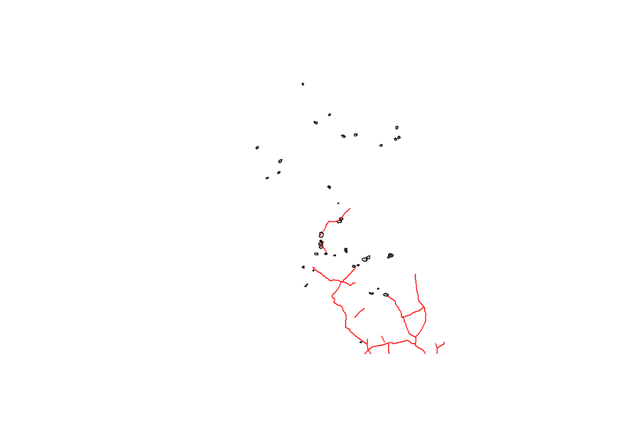

```r
plot(scot_battles)
lines(roman_roads_osgb, col = "red")
```

To make the distance analysis easier, let’s calculate the centroid point of each battlefield site.

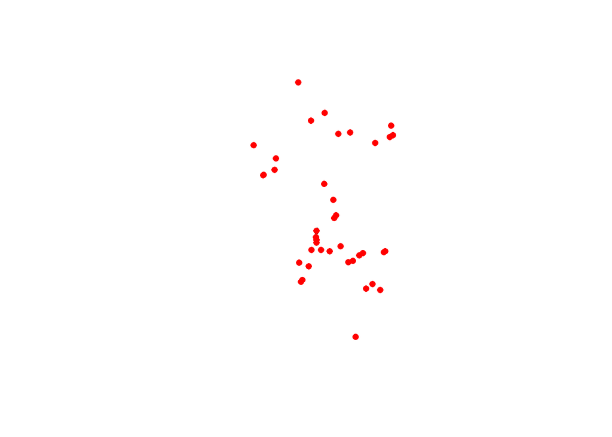

```r
scot_battles_centroid <- gCentroid(scot_battles, byid = TRUE)
plot(scot_battles)
points(scot_battles_centroid, col = "red", pch = 16, cex = 1)
```

Right now, the battlefield centroids lack any data. Let’s add when the battle occured.

```r
bf_dates <- NULL

# loops through the URLs in the scot_battles dataset. extracts the corresponding HTML for battledates and substrings to pull out the date. Writes to bf_dates.

for (i in 1:length(scot_battles$LINK)) {
  bf_date_string <- rvest::html_nodes(read_html(paste0(scot_battles$LINK[i], collapse = "")), ".battledate")
  bf_date_stringcut <-  unlist(str_extract_all(bf_date_string,"[[:digit:]]{4}"))
  bf_dates[i] <- as.vector(bf_date_stringcut)
  Sys.sleep(2)
}

bf_dates <- as.numeric(bf_dates)

# adds data to scot_battles_centroid to make it a SpatialPointsDataFrame class.

scot_battles_centroid <- SpatialPointsDataFrame(scot_battles_centroid, as.data.frame(bf_dates))

str(scot_battles_centroid)
```

```
## Formal class 'SpatialPointsDataFrame' [package "sp"] with 5 slots
##   ..@ data       :'data.frame':  40 obs. of  1 variable:
##   .. ..$ bf_dates: num [1:40] 1645 1545 1645 1314 1679 ...
##   ..@ coords.nrs : num(0)
##   ..@ coords     : num [1:40, 1:2] 356813 362938 291289 280576 271003 ...
##   .. ..- attr(*, "dimnames")=List of 2
##   .. .. ..$ : chr [1:40] "0" "1" "2" "3" ...
##   .. .. ..$ : chr [1:2] "x" "y"
##   ..@ bbox       : num [1:2, 1:2] 199566 566273 379623 894431
##   .. ..- attr(*, "dimnames")=List of 2
##   .. .. ..$ : chr [1:2] "x" "y"
##   .. .. ..$ : chr [1:2] "min" "max"
##   ..@ proj4string:Formal class 'CRS' [package "sp"] with 1 slot
##   .. .. ..@ projargs: chr "+proj=tmerc +lat_0=49 +lon_0=-2 +k=0.9996012717 +x_0=400000 +y_0=-100000 +datum=OSGB36 +units=m +no_defs +ellps"| __truncated__
```

To look at how the data changes over time more easily, let’s create a new column that classifies the dates into the century in which it’s in.

```r
scot_battles_centroid$century <- cut(scot_battles_centroid$bf_dates, breaks = c(1200,1300,1400,1500,1600,1700,1800),labels = c("1200s", "1300s", "1400s", "1500s", "1600s", "1700s"), include.lowest = TRUE)

str(scot_battles_centroid)
```

```
## Formal class 'SpatialPointsDataFrame' [package "sp"] with 5 slots
##   ..@ data       :'data.frame':  40 obs. of  2 variables:
##   .. ..$ bf_dates: num [1:40] 1645 1545 1645 1314 1679 ...
##   .. ..$ century : Factor w/ 6 levels "1200s","1300s",..: 5 4 5 2 5 6 5 2 6 6 ...
##   ..@ coords.nrs : num(0)
##   ..@ coords     : num [1:40, 1:2] 356813 362938 291289 280576 271003 ...
##   .. ..- attr(*, "dimnames")=List of 2
##   .. .. ..$ : chr [1:40] "0" "1" "2" "3" ...
##   .. .. ..$ : chr [1:2] "x" "y"
##   ..@ bbox       : num [1:2, 1:2] 199566 566273 379623 894431
##   .. ..- attr(*, "dimnames")=List of 2
##   .. .. ..$ : chr [1:2] "x" "y"
##   .. .. ..$ : chr [1:2] "min" "max"
##   ..@ proj4string:Formal class 'CRS' [package "sp"] with 1 slot
##   .. .. ..@ projargs: chr "+proj=tmerc +lat_0=49 +lon_0=-2 +k=0.9996012717 +x_0=400000 +y_0=-100000 +datum=OSGB36 +units=m +no_defs +ellps"| __truncated__
```

# Spatial visualisation

```r
bf_pts <- as.data.frame(scot_battles_centroid)

roman_roads_df <- fortify(roman_roads_osgb)

uk_outline <- getData("GADM", country="GBR", level=1)

scotland_outline <- uk_outline[uk_outline$NAME_1 == "Scotland",]

scotland_outline_osgb <- spTransform(scotland_outline, crs(scot_battles_centroid))

scotland_outline_osgb_df <- fortify(scotland_outline_osgb, region="NAME_1")
```

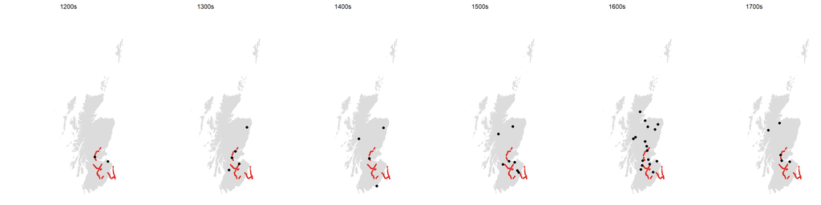

```r
map_plot <- ggplot(data = bf_pts, (aes(x, y))) +
  geom_polygon(data = scotland_outline_osgb_df, aes(x = long, y = lat, group = group), fill = "gainsboro") +
  geom_point(data = roman_roads_df[roman_roads_df$lat > 600000,], aes(x = long, y = lat ), colour = "#de2d26", size = 0.6) +
  geom_point() +
  facet_wrap(~century, nrow = 1) +
    theme_void()

map_plot
```

# Distance Analysis

```r
coords <- cbind(roman_roads_df$long, roman_roads_df$lat)
roman_roads_pts <-  SpatialPoints(coords)

crs(roman_roads_pts) <- proj4string(scot_battles_centroid)
```

```r
distance <- data.frame()

for (i in levels(scot_battles_centroid$century)) {
  battle_road_dist <- rgeos::gDistance(scot_battles_centroid[scot_battles_centroid$century == i,], roman_roads_pts, byid = TRUE)
  battle_road_dist_vect <- data.frame(as.vector(battle_road_dist))
  battle_road_dist_vect$century <- i
  distance <- rbind(distance, battle_road_dist_vect)
}

names(distance) <- c("Distance", "Century")
```

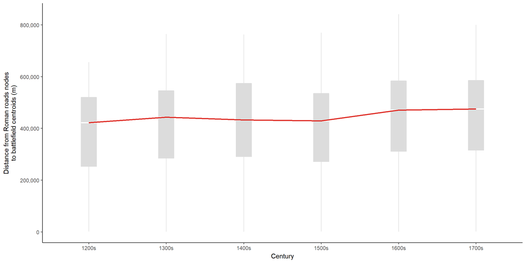

```r
box_dist <- ggplot(distance, aes(Century, Distance)) +
  geom_boxplot(colour = "gainsboro", fill = "gainsboro", width = 0.2) +  stat_summary(geom = "crossbar", width=0.2, fatten=2, colour="white", fun.data = function(x){ return(c(y=median(x), ymin=median(x), ymax=median(x))) })  +
  theme_classic() +
  scale_y_continuous(labels = comma) +
  stat_summary(fun.y= median, geom="line", aes(group=1), colour = "#de2d26", size = 1) +
  theme(plot.title = element_text(size = 16, colour = "#de2d26"))

box_dist + labs(y = "Distance from Roman roads nodes\nto battlefield centroids (m)")
```

# Buffer Analysis

```r
buffer <- data.frame()

for (i in c(1000, 2500, 5000, 10000, 25000)) {
  road_buff <- rgeos::gBuffer(roman_roads_osgb, byid = TRUE, width = i, capStyle = "ROUND", joinStyle = "ROUND")
  over <- sp::over(scot_battles_centroid, road_buff)
  over_pts <- scot_battles_centroid[!is.na(over$OBJECTID),]
  over_pts_proportion <- data.frame((tapply(over_pts$century, over_pts$century,length)) / (tapply(scot_battles_centroid$century, scot_battles_centroid$century, length)))
  over_pts_proportion$buffer <- i
  over_pts_proportion$decade <- rownames(over_pts_proportion)
  buffer <- rbind(buffer, over_pts_proportion)
}

str(buffer)
```

```
## 'data.frame':    30 obs. of  3 variables:
##  $ X.tapply.over_pts.century..over_pts.century..length....tapply.scot_battles_centroid.century..: Named num  NA 0.2 NA NA 0.0588 ...
##   ..- attr(*, "names")= chr  "1200s" "1300s" "1400s" "1500s" ...
##  $ buffer                                                                                       : num  1000 1000 1000 1000 1000 1000 2500 2500 2500 2500 ...
##  $ decade                                                                                       : chr  "1200s" "1300s" "1400s" "1500s" ...
```

```r
names(buffer) <- c("battlefield.proport", "Distance", "Century")

buffer$Distance <- as.factor(buffer$Distance)
buffer$Century <- as.factor(buffer$Century)

levels(buffer$Distance) <- c("1,000m from Roman roads", "2,500m from Roman roads", "5,000m from Roman roads", "10,000m from Roman roads", "25,000m from Roman roads")
```

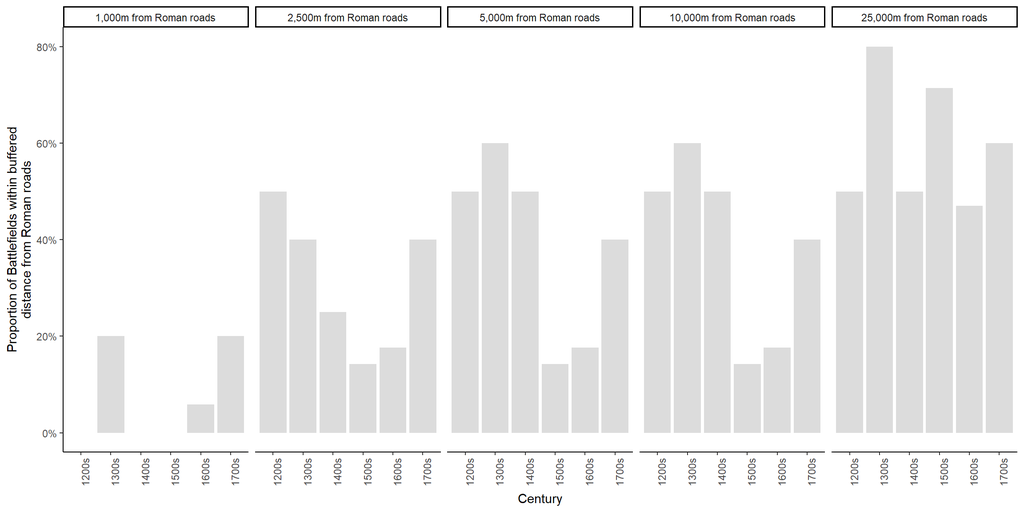

```r
distance_plot <- ggplot(buffer) +
  geom_bar(aes(x = Century, y = battlefield.proport), fill = "gainsboro", stat = "identity") +
  facet_wrap(~Distance, nrow = 1) +
  labs(x = "Century", y = "Proportion of Battlefields within buffered\ndistance from Roman roads") +
  scale_y_continuous(labels = scales::percent) +
  theme_classic() +
  theme(axis.text.x = element_text(angle = 90, hjust = 1))

distance_plot
```

```r
agg_dist <- aggregate(buffer$battlefield.proport, by = list(buffer$Distance), max, na.rm  = TRUE)

agg_dist$ismax <- "Max"

buffermax <- merge(buffer, agg_dist, by.x = c("battlefield.proport", "Distance"), by.y = c("x", "Group.1"), all.x = TRUE)

buffermax$ismax[is.na(buffermax$ismax)] <- "NotMax"

levels(buffermax$Distance) <- c("1,000m from Roman roads", "2,500m from Roman roads", "5,000m from Roman roads", "10,000m from Roman roads", "25,000m from Roman roads")
```

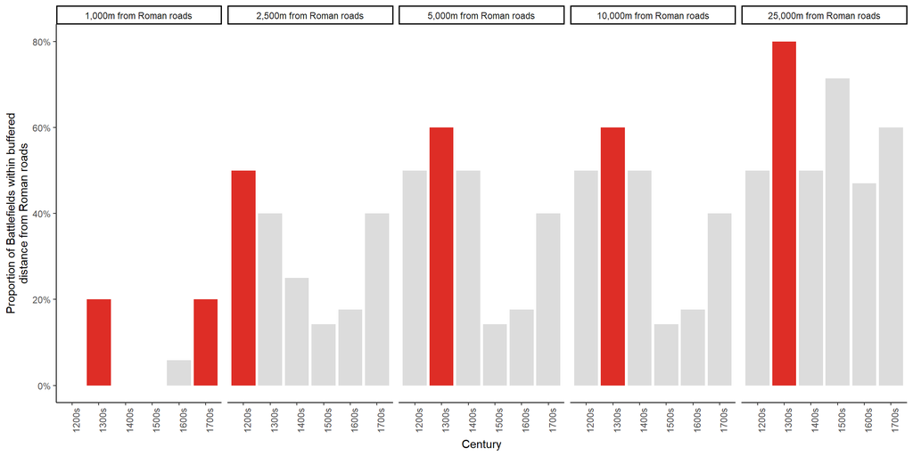

```r
distance_max_plot <- ggplot(buffermax) +
  geom_bar(aes(x = Century, y = battlefield.proport, fill = ismax), stat = "identity") +
  scale_fill_manual(values = c('#de2d26', "gainsboro")) +
  facet_wrap(~Distance, nrow = 1) +
  labs(x = "Century", y = "Proportion of Battlefields within buffered\ndistance from Roman roads") +
  scale_y_continuous(labels = scales::percent) +
  theme_classic() +
  guides(fill = FALSE) +
  theme(axis.text.x = element_text(angle = 90, hjust = 1))

distance_max_plot
```